# Functions in R

Introduction to R and RStudio

Gerko Vink

Javier Garcia-Bernardo

Hanne Oberman

2025-11-28

## Recap:

#### Last week

- Intro to R/Rstudio: Data types and structures
- Subsetting structures
- Choice statements and for-loops
- Reproducibility (renv)
- Best practices (e.g., naming conventions)
- Reading and writing files in several formats

#### Today

- Functions
- Inferential statistics: A 5-min primer of linear regression
- Principles of tidy data and short comparison of base R and the tidyverse
- Data wrangling with the tidyverse
- Speeding up queries in large datasets

# Writing your own functions

## What are functions?

Functions are reusable pieces of code that

1. take some standard input (e.g. a vector of numbers)
2. do some computation (e.g. calculate the mean)
3. return some standard output (e.g. one number with the mean)

We have been using a lot of functions: code of the form `something()` is usually a function.

```r
mean(1:6)
```

```
[1] 3.5
```

## Our own function

We can make our own functions as follows:

```r
squared <- function(x){
  x_square <- x * x
  return(x_square)
}

squared(4)
```

```
[1] 16
```

`x`, the input, is called the (formal) *argument* of the function. `x_square` is called the *return value*.

## Our own function

If there is no `return()`, the last line is automatically returned, so we can also just write:

```r
square <- function(x){
  x * x
}

square(-2)
```

```
[1] 4
```

I do not recommend this, please always specify what you return unless you have a one-line function.

## Anonymous/Lambda expressions

```r
df <- data.frame("V1" = rnorm(5),
                 "V2" = rnorm(5, mean = 5, sd = 2),
                 "V3" = rnorm(5, mean = 6, sd = 1))

head(df)
```

```
          V1       V2       V3
1 -1.7956516 5.508671 5.439229
2 -1.2437913 3.815288 7.103663
3  0.4238173 6.813016 4.345031
4 -0.5414766 2.977138 7.152863
5  1.0492275 3.527580 5.565280
```

```python
#Python
df.apply(lambda x: np.percentile(x, .42))
```

```r
#R
sapply(df, {function(x) quantile(x, .42)})
```

```
    V1.42%     V2.42%     V3.42%
-0.7662173  3.7232212  5.5249435
```

## Default options in functions

- Default options for some arguments are provided in many functions.
- They allow us to provide additional (optional) arguments

```r
is_contained <- function(str_1, str_2, print_input = TRUE){
  if (print_input){
    cat("Testing if", str_1, "contained in", str_2, "\n")
  }
  return(str_1 %in% str_2)
}
```

```r
is_contained("R", "rstudio")
```

```r
is_contained("R", "rstudio")
## Testing if R contained in rstudio
## [1] FALSE
is_contained("R", "rstudio", print_input = TRUE)
## Testing if R contained in rstudio
## [1] FALSE
is_contained("R", "rstudio", print_input = FALSE)
## [1] FALSE
```

## Create documentation of functions

```python
##Python
def square(x):
  """
  Squares a number

  Parameters:
  x (float): Number (or vector)

  Returns:
  float: Squared numbers
  """
  return(x**2)
```

```r
##R more info at https://r-pkgs.org/man.html

#' Squares a number
#'
#' @param x A number.
#' @returns A numeric vector.
#' @examples
#' square(3)
square <- function(x){
  return(x * x)
}
```

## Troubleshooting

- Your first self-written for-loop, or function, will probably not work.
- Don’t panic! Just go line-by-line, keeping track of what is currently inside each variable.
- Stackoverflow and LLMs are your friends.

# Scoping rules in `R`

## Global environemnt (workspace)

When you write the name of a variable, R needs to find the value.

In the interactive computation (outside of functions, e.g., your console), this happens in the following order:

- First, search the global environment (i.e., your workspace)
- If it cannot be found, search each of the loaded packages

```r
search()
```

```
[1] ".GlobalEnv"        "package:stats"     "package:graphics"
[4] "package:grDevices" "package:utils"     "package:datasets"
[7] "package:methods"   "Autoloads"         "package:base"
```

The order of packages is important.

## Scoping rules in `R`: Functions

Inside a function, this happens in the following order:

- First, search within the function.
- If it cannot be found, search in the global environment (i.e., your workspace)
- If it cannot be found, search each of the loaded packages

```r
y <- 3
test_t <- function() {
  print(y)
}
test_t()
## [1] 3
```

```r
y <- 3
test_t <- function() {
  y <- 2
  print(y)
}
test_t()
## [1] 2
```

## Scoping rules in `R`: Functions

What happens inside a function, stays within a function (unless you specify it differently)

```r
y <- 3
test_t <- function() {
  y <- 2
  print(y)
}
test_t()
```

```
[1] 2
```

```r
y
```

```
[1] 3
```

## Scoping rules in `R`: Packages

Packages are neatly contained/isolated, so they are not affected by your code. They do so through namespaces:

- Namespaces allow the package developer to hide functions and data.
- Objects in the global environment that match objects in the function’s namespace are ignored when running functions from packages (prevent clashes)
- Functions are executed within the namespace of the package and have access to the global environment
- They provide a way to refer to an object, with the double colon `::`

```r
dplyr::n_distinct(c(1,2,3,4,2))
```

```
[1] 4
```

## Scoping rules in `R`: Packages (good practices)

- Pass to the function (using arguments) *everything* that the function needs to use (i.e. don’t define something outside the function that is being used for the function)

BAD

```r
shifted_mean <- function(numbers) {
   return(mean(numbers) + shift_by)
}

shift_by <- 3
shifted_mean(c(1,2,3))
```

GOOD

```r
shifted_mean <- function(numbers, shift_by) {
   return(mean(numbers) + shift_by)
}

shift_by <- 3
shifted_mean(c(1,2,3), shift_by)
```

# Modeling

## Linear regression (model)

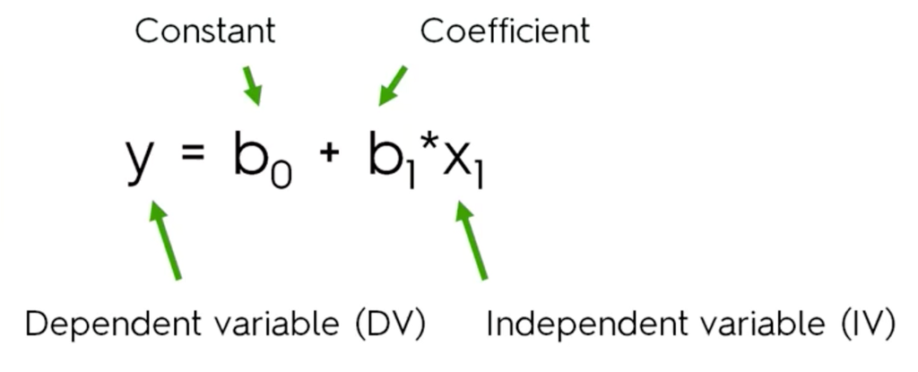

Linear regression. Source: R. Kukuh (medium)

## Linear regression (visual interpretation)

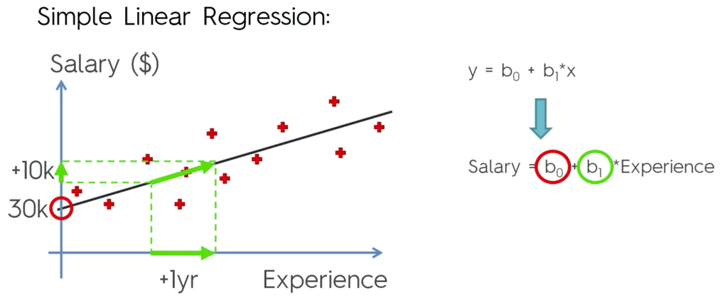

Linear regression. Source: R. Kukuh (medium)

## Linear regression (fitting)

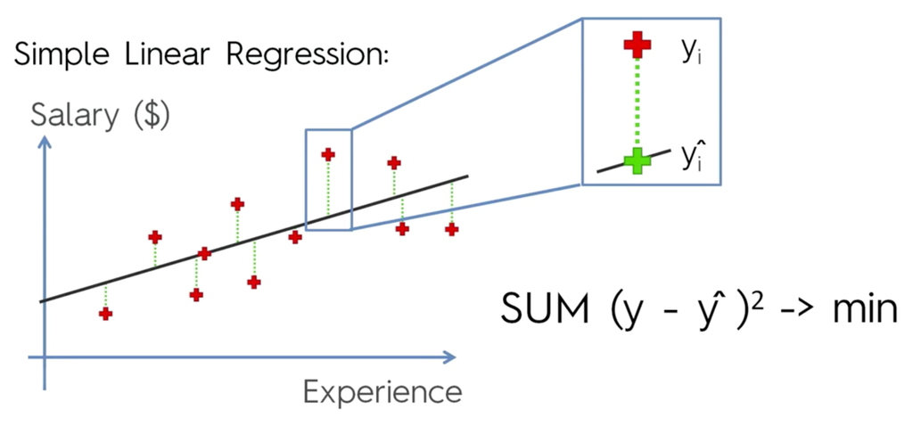

Linear regression. Source: R. Kukuh (medium)

## Modeling in `R`

To model objects based on other objects, we use `~` (tilde)

For example, to model the relationship between body mass index (bmi) and weight, we would type

```r
bmi ~ weight
```

The `~` is used to separate the dependent variable (left side) from the independent variables (right side).

For functions within the formula we use `I()`. For example, to model body mass index (BMI) on its deterministic function of weight and height, we would type

```r
bmi ~ I(weight / height^2)
```

## We can then plug the formula into a model.

Let’s use the boys dataset.

```r
lm(bmi ~ wgt, data = boys)
##
## Call:
## lm(formula = bmi ~ wgt, data = boys)
##
## Coefficients:
## (Intercept)          wgt
##     14.5401       0.0935
```

```r
lm(bmi ~ I(wgt / (hgt / 100)^2), data = boys)
##
## Call:
## lm(formula = bmi ~ I(wgt/(hgt/100)^2), data = boys)
##
## Coefficients:
##        (Intercept)  I(wgt/(hgt/100)^2)
##          -0.005553            1.000034
```

## Why we really need `I()`

```r
lm(bmi ~ wgt + wgt^2, data = boys)
##
## Call:
## lm(formula = bmi ~ wgt + wgt^2, data = boys)
##
## Coefficients:
## (Intercept)          wgt
##     14.5401       0.0935

lm(bmi ~ wgt + I(wgt^2), data = boys)
##
## Call:
## lm(formula = bmi ~ wgt + I(wgt^2), data = boys)
##
## Coefficients:
## (Intercept)          wgt     I(wgt^2)
##   16.271466    -0.041715     0.001604
```

## More efficient

It is better to store the output from the function in an object. The convention for regression models is an object called `fit`.

```r
fit <- lm(bmi ~ I(wgt / (hgt / 100)^2), data = boys)
```

The object `fit` contains a lot more than just the regression weights. To inspect what is inside you can use `attributes()`

```r
attributes(fit)
```

```
$names
 [1] "coefficients"  "residuals"     "effects"       "rank"
 [5] "fitted.values" "assign"        "qr"            "df.residual"
 [9] "na.action"     "xlevels"       "call"          "terms"
[13] "model"

$class
[1] "lm"
```

## Finding the coefficients

```r
summary(fit)
```

```
Call:
lm(formula = bmi ~ I(wgt/(hgt/100)^2), data = boys)

Residuals:
      Min        1Q    Median        3Q       Max
-0.005195 -0.002381  0.000152  0.002322  0.005125

Coefficients:
                     Estimate Std. Error   t value Pr(>|t|)
(Intercept)        -5.553e-03  6.366e-04    -8.724   <2e-16 ***
I(wgt/(hgt/100)^2)  1.000e+00  3.473e-05 28795.609   <2e-16 ***
---
Signif. codes:  0 '***' 0.001 '**' 0.01 '*' 0.05 '.' 0.1 ' ' 1

Residual standard error: 0.002857 on 725 degrees of freedom
  (21 observations deleted due to missingness)
Multiple R-squared:      1, Adjusted R-squared:      1
F-statistic: 8.292e+08 on 1 and 725 DF,  p-value: < 2.2e-16
```

## Classes in R

```r
class(fit)
```

```
[1] "lm"
```

Classes are used in object-oriented programming. It defines a set of properties and methods that are common to all objects of one type. For example, no matter what model you fit, you’ll always need some common attributes.

In `R`, objects are the instances of a class (i.e., all objects in R have a class).

When you apply a generic function to an object (e.g. class = “lm”), R first tries to find a function of the class of the object.

When a generic function function (e.g. `plot()`) is applied to an object with class attribute `"lm"`, the system searches for a function called `plot.lm()` and, if it finds it, applies it to the object.

## Classes example: plotting without class

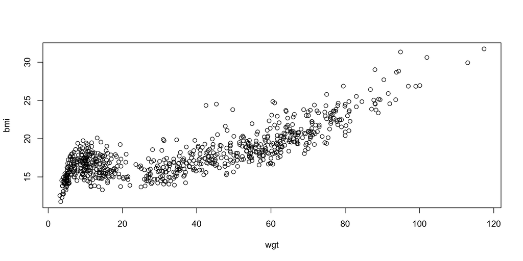

```r
plot(bmi ~ wgt, data = boys)
```

## Classes example: plotting with class

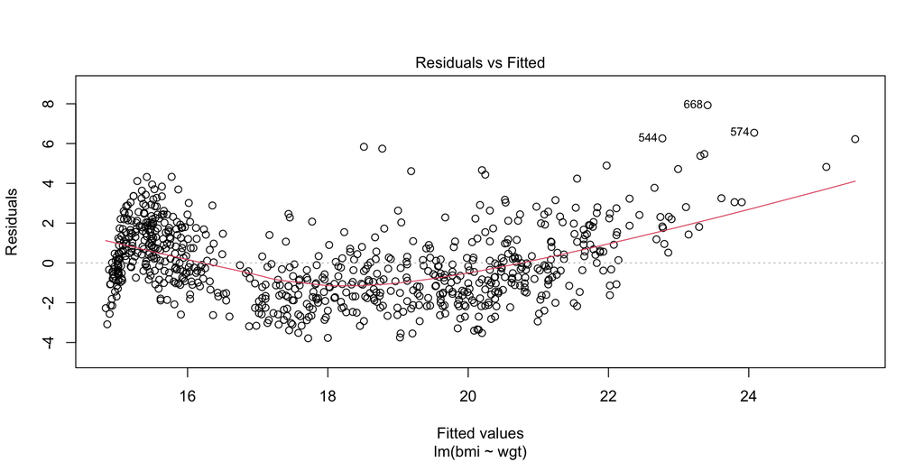

```r
plot(lm(bmi ~ wgt, data = boys), which = 1)
```

## Classes example: plotting with class

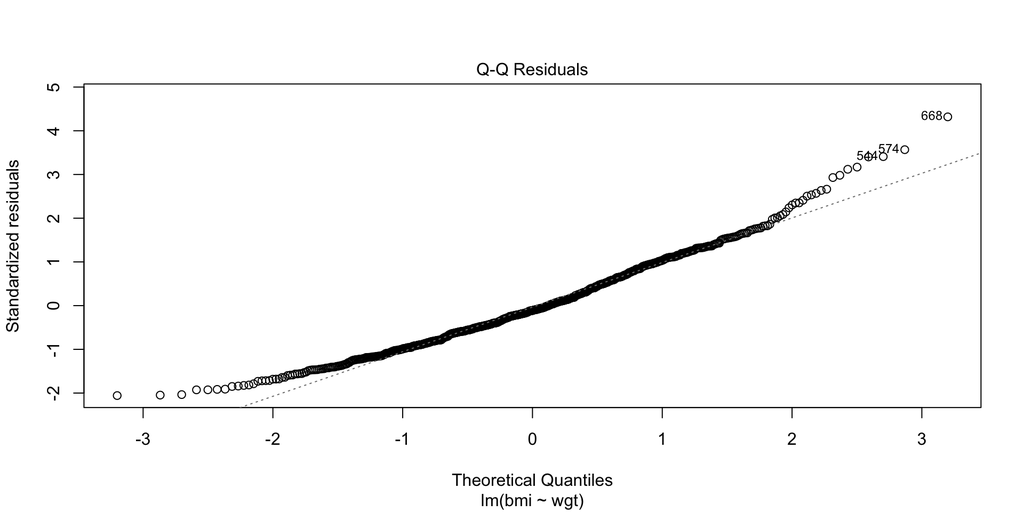

```r
plot(lm(bmi ~ wgt, data = boys), which = 2)
```

## Classes example: plotting with class

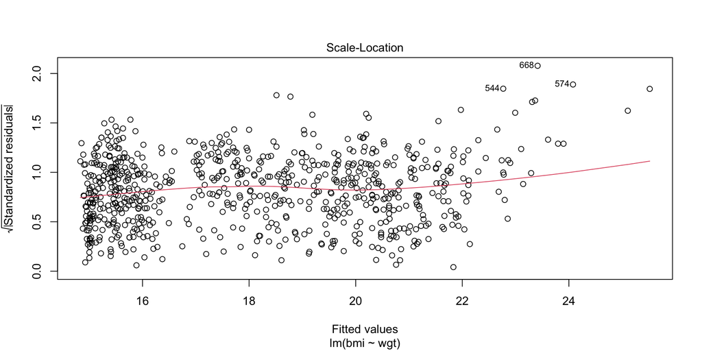

```r
plot(lm(bmi ~ wgt, data = boys), which = 3)
```

## Classes example: plotting with class

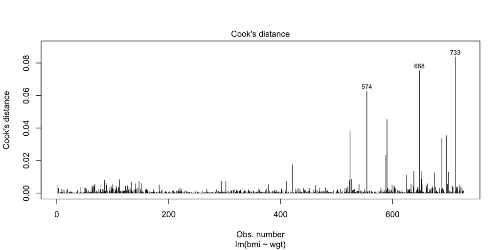

```r
plot(lm(bmi ~ wgt, data = boys), which = 4)
```

## Classes example: plotting with class

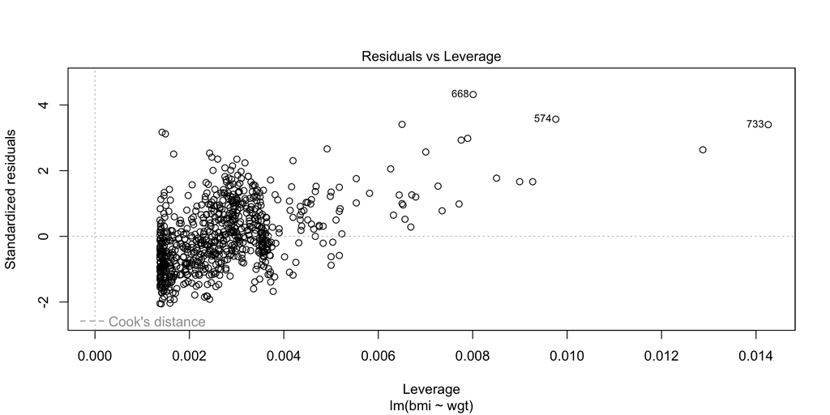

```r
plot(lm(bmi ~ wgt, data = boys), which = 5)
```

## Classes example: plotting with class

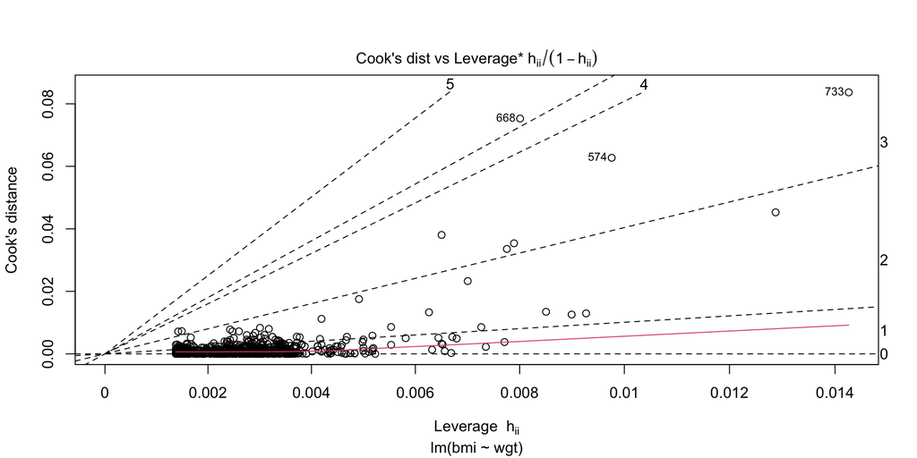

```r
plot(lm(bmi ~ wgt, data = boys), which = 6)
```